# Building a Predictive Model for Weight Lifting Exercises Dataset

## Pratical Machile Learning Writeup

Researchers from PUC Rio developed a dataset in which collected a large amount of data about weight lifting exercises. This report show how was built a predictive model to predict the manner in which the people did the activity. The data for this project come from this source: http://groupware.les.inf.puc-rio.br/har.

### Preparing the Enviorment

To work in easiest place, we can change the default work directory (WD) to a specific folder. If we don’t do this, the files downloaded and generated will be stored in the default WD.

```r
# setwd("~/coursera/predmachlearn")
```

We have to work with a library. So, let’s load it:

```r
library(caret, quietly = TRUE)
library(randomForest)
```

Now, load (or download) the training dataset:

```r
if (!file.exists("./pml-training.csv")) {
  download.file("http://d396qusza40orc.cloudfront.net/predmachlearn/pml-training.csv",
                destfile = "./pml-training.csv")
}
training = read.csv("./pml-training.csv", header = TRUE, na.strings = c("NA", ""), stringsAsFactors = T)
```

### Data Analysis

Look to the dataset dimension:

```r
dim(training)
```

```
## [1] 19622   160
```

```
## [1] "it means 19622 observations 160 predictors"
```

A barplot show us the proportion of each “classe”.

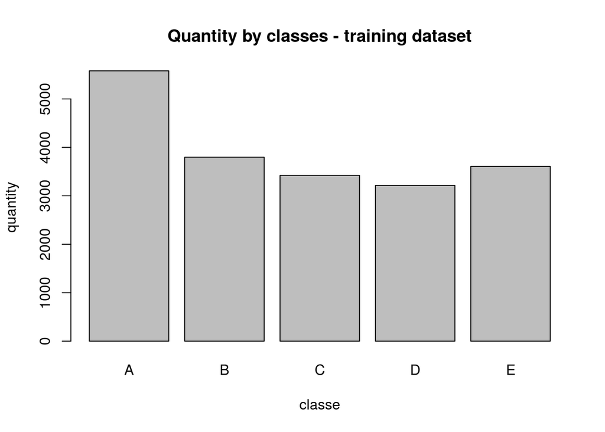

```r
barplot(table(training$classe), xlab="classe", ylab="quantity", main="Quantity by classes - training dataset")
```

How many are completed? In other words, how many has no missing value?

```r
complete.observations <- sum(complete.cases(training))
paste("only", complete.observations, "from a total of ", dim(training)[1])
```

```
## [1] "only 406 from a total of  19622"
```

A lot of observations is considered uncomplete because of bad variables. In preference to work with more observations, let’s ignore these bad predictors. It is a radical decision: if a predictor has one missing value, it will be discarted! We are ignoring predictors with identification, which has no value to out prediction, and with no, or almost no, variance too.

```r
# Keep only predictors with no missing values
columns.to.keep <- colSums(is.na(training)) == 0
training <- training[,columns.to.keep]
# Remove predictors with almost no variance
columns.to.remove <- nearZeroVar(training)
training <- training[,-columns.to.remove]
# Remove first 6 columns with only identification data (index, user, window etc)
training <- training[,-(1:6)]
```

### Build a Model

Let’s consider that the dataset came splited (training and testing). So the model will be created using the whole training data. Set a seed to reproducibility:

```r
set.seed(5584)
```

How much more trees in the model, better. However, the computer get slow and more memory is used. A good number of trees to this model is 512 because have a good error rate with less than 50MB.

```r
model <- randomForest(classe ~ ., data = training, ntree = 512)
model
```

```
##
## Call:
##  randomForest(formula = classe ~ ., data = training, ntree = 512)
##                Type of random forest: classification
##                      Number of trees: 512
## No. of variables tried at each split: 7
##
##         OOB estimate of  error rate: 0.29%
## Confusion matrix:
##      A    B    C    D    E  class.error
## A 5577    2    0    0    1 0.0005376344
## B   11 3783    3    0    0 0.0036871214
## C    0    9 3413    0    0 0.0026300409
## D    0    0   22 3192    2 0.0074626866
## E    0    0    2    4 3601 0.0016634322
```

We can see the number of trees, error rate and a good confusion matrix. Look to variable importance to the prediction: each predictor and its importance/overall.

```r
varImp(model)
```

```
##                         Overall
## roll_belt            1301.22653
## pitch_belt            712.01396
## yaw_belt              909.35795
## total_accel_belt      223.31554
## gyros_belt_x           92.17334
## gyros_belt_y          114.45786
## gyros_belt_z          287.39052
## accel_belt_x          115.33285
## accel_belt_y          137.83682
## accel_belt_z          385.36658
## magnet_belt_x         255.29119
## magnet_belt_y         380.96628
## magnet_belt_z         399.23731
## roll_arm              322.50308
## pitch_arm             176.84663
## yaw_arm               248.81838
## total_accel_arm       102.13358
## gyros_arm_x           132.49441
## gyros_arm_y           130.48163
## gyros_arm_z            56.84052
## accel_arm_x           226.10699
## accel_arm_y           152.29771
## accel_arm_z           129.31625
## magnet_arm_x          226.40396
## magnet_arm_y          239.59929
## magnet_arm_z          191.25494
## roll_dumbbell         425.69017
## pitch_dumbbell        173.81810
## yaw_dumbbell          246.29506
## total_accel_dumbbell  268.33908
## gyros_dumbbell_x      128.32864
## gyros_dumbbell_y      251.28768
## gyros_dumbbell_z       79.88762
## accel_dumbbell_x      245.18633
## accel_dumbbell_y      403.99001
## accel_dumbbell_z      325.95286
## magnet_dumbbell_x     489.77673
## magnet_dumbbell_y     687.36283
## magnet_dumbbell_z     761.05084
## roll_forearm          611.66117
## pitch_forearm         806.89391
## yaw_forearm           169.40908
## total_accel_forearm   114.88837
## gyros_forearm_x        72.10916
## gyros_forearm_y       120.92754
## gyros_forearm_z        79.27882
## accel_forearm_x       325.33978
## accel_forearm_y       137.41036
## accel_forearm_z       237.19363
## magnet_forearm_x      206.97585
## magnet_forearm_y      213.52800
## magnet_forearm_z      280.62350
```

## Prediction on train dataset

We can apply the model in a dataset like it is done in the next line.

```r
prediction <- predict(model, training)
```

This line create a list with a class for each observation in the dataset, in this case 19622. Let’s see the head of this result (prediction):

```r
head(prediction, n=20)
```

```
##  1  2  3  4  5  6  7  8  9 10 11 12 13 14 15 16 17 18 19 20
##  A  A  A  A  A  A  A  A  A  A  A  A  A  A  A  A  A  A  A  A
## Levels: A B C D E
```

## Applying the model to the test dataset

The test dataset has 20 observation and we will apply the model to predict the “classe” for each one.

```r
if (!file.exists("./pml-testing.csv")) {
  download.file("http://d396qusza40orc.cloudfront.net/predmachlearn/pml-testing.csv",
                destfile = "./pml-testing.csv")
}
testing = read.csv("./pml-testing.csv", header = TRUE, na.strings = c("NA", ""), stringsAsFactors = T)
```

```r
prediction <- predict(model, testing)
```

```r
head(prediction, n=3) # yes, only 3
```

```
## 1 2 3
## B A B
## Levels: A B C D E
```

## Processing time

The process time, in seconds, for the model building, the predicting step and the whole report/project.

```
## [1] "model time 94.036"
```

```
## [1] "prediction time 0.122"
```

```
## [1] "project time 111.569"
```

## Submission

To send the result we have put each prediction in a file. The script offered is used:

```r
pml_write_files = function(x){
  n = length(x)
  for(i in 1:n){
    filename = paste0("problem_id_",i,".txt")
    write.table(x[i],file=filename,quote=FALSE,row.names=FALSE,col.names=FALSE)
  }
}

pml_write_files(prediction)
```

## Conclusion

With the model generated we can get a good prediction and its use in the testing dataset can be considered a success.